# PA1_template

Elizabeth Eason

February 8, 2017

## Reading in the data

```r
setwd("/Users/Lizzie Eason/Desktop/Coursera/5_ReproducibleResearch")
unzip("repdata_data_activity.zip")
fit<-read.csv("activity.csv")
head(fit)
```

```
##   steps       date interval
## 1    NA 2012-10-01        0
## 2    NA 2012-10-01        5
## 3    NA 2012-10-01       10
## 4    NA 2012-10-01       15
## 5    NA 2012-10-01       20
## 6    NA 2012-10-01       25
```

## Calculating the total number of steps per day

```r
totstep<-aggregate(steps ~ date, data = fit, sum, na.rm = TRUE)
head(totstep)
```

```
##         date steps
## 1 2012-10-02   126
## 2 2012-10-03 11352
## 3 2012-10-04 12116
## 4 2012-10-05 13294
## 5 2012-10-06 15420
## 6 2012-10-07 11015
```

## Creating a historgram of the total number of steps taken per day

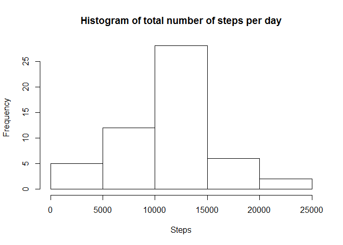

```r
hist(totstep[,2], main="Histogram of total number of steps per day", xlab="Steps")
```

## Calculating the mean and median

```r
mean(totstep[,2])
```

```
## [1] 10766.19
```

```r
median(totstep[,2])
```

```
## [1] 10765
```

## Graphing mean number of steps per interval

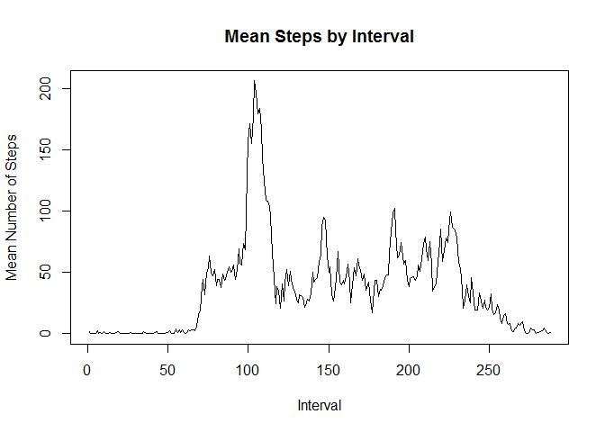

```r
meanstep<-aggregate(fit[,1],list(fit$interval),function(x){
  mean(x,na.rm=TRUE)
})
plot(meanstep[,2],type="l",main="Mean Steps by Interval", ylab="Mean Number of Steps",xlab="Interval")
```

```r
meanstep[max(meanstep[,2]),]
```

```
##     Group.1        x
## 206    1705 56.30189
```

## Number of rows with NA entries

```r
sum(!complete.cases(fit))
```

```
## [1] 2304
```

## Imputing the Data

First, we write a function to replace the NA values in step. The function replaces NA step values with the mean of the steps for that day with all NA’s removed, or, if all of the entries for a single day are NA (as is the case with 2012-10-01), then it replaces the NA’s with the overall mean of the data with NA’s removed.

```r
replacemeant<-function(x){
  for (i in 1:length(x)){
    if (is.na(x[i])){
      if (is.na(mean(x[fit$date==fit$date[i]],na.rm=TRUE)))
      {x[i]<-mean(x,na.rm=TRUE)}
      else
      {x[i]<-mean(x[fit$date==fit$date[i]],na.rm=TRUE)}}
    else x[i]<-x[i]
  }
  x}
```

Next, we apply this function to the steps column and make a new variable, and remove the old variable from the data.

```r
fit$newsteps<-replacemeant(fit$steps)
library(dplyr)
fit2<-select(fit,-steps)
head(fit2)
```

```
##         date interval newsteps
## 1 2012-10-01        0  37.3826
## 2 2012-10-01        5  37.3826
## 3 2012-10-01       10  37.3826
## 4 2012-10-01       15  37.3826
## 5 2012-10-01       20  37.3826
## 6 2012-10-01       25  37.3826
```

## Total steps taken per day with new data

```r
totstep2<-aggregate(fit2[,3],list(fit2$date),function(x){
  sum(x,na.rm=TRUE)
})
head(totstep2)
```

```
##      Group.1        x
## 1 2012-10-01 10766.19
## 2 2012-10-02   126.00
## 3 2012-10-03 11352.00
## 4 2012-10-04 12116.00
## 5 2012-10-05 13294.00
## 6 2012-10-06 15420.00
```

## Histogram

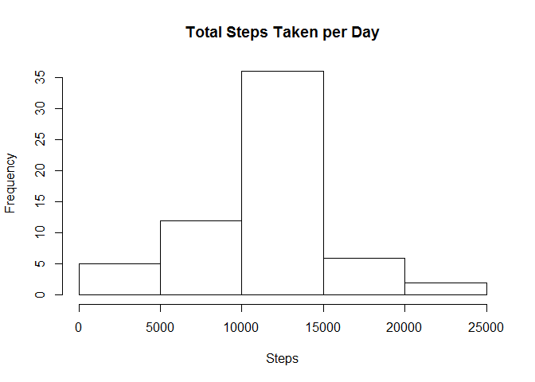

```r
hist(totstep2[,2],main="Total Steps Taken per Day",xlab="Steps")
```

## Calculating the mean and median with new data

```r
mean(totstep2[,2])
```

```
## [1] 10766.19
```

```r
median(totstep2[,2])
```

```
## [1] 10766.19
```

## Making a weekend indicator:

```r
fit2$fitweekday<-sapply(as.Date(fit2$date),weekdays)
fit2$weekendind<-ifelse(fit2$fitweekday=="Saturday"|fit2$fitweekday=="Sunday","weekend","weekday")
head(fit2)
```

```
##         date interval newsteps fitweekday weekendind
## 1 2012-10-01        0  37.3826     Monday    weekday
## 2 2012-10-01        5  37.3826     Monday    weekday
## 3 2012-10-01       10  37.3826     Monday    weekday
## 4 2012-10-01       15  37.3826     Monday    weekday
## 5 2012-10-01       20  37.3826     Monday    weekday
## 6 2012-10-01       25  37.3826     Monday    weekday
```

# Plotting the mean total number of steps in each interval by the weekend indicator

```r
meanstep2<-aggregate(fit2[,3],list(fit2$interval,fit2$weekendind),function(x){
  mean(x,na.rm=TRUE)
})
head(meanstep2)
```

```
##   Group.1 Group.2        x
## 1       0 weekday 7.006569
## 2       5 weekday 5.384347
## 3      10 weekday 5.139902
## 4      15 weekday 5.162124
## 5      20 weekday 5.073235
## 6      25 weekday 6.295458
```

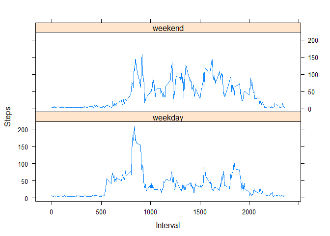

```r
library(lattice)
xyplot(meanstep2[,3]~meanstep2[,1]|meanstep2[,2], data=fit2, type="l",layout=c(1,2),xlab="Interval",ylab="Steps")
```